# Etap 5: Interakcje

# 1 Podsumowanie wyników

W tej części zbadaliśmy interakcje wybranych zmiennych. W szczególności przeanalizowaliśmy interakcje pomiędzy wykształceniami rodziców, interakcje pomiędzy płcią a krajem, oraz interakcje różnych zmiennych z punktacją za zadanie.

W przypadku wykształcenia rodziców za pomocą regresji segmentowej zbadaliśmy trend wpływu na czas rozwiązywania zadania. Odkryliśmy że im bardziej wykształceni są rodzice, tym dłużej uczeń rozwiązuje zadanie. Zachodzi tutaj bardzo silna interakcja: W przypadku jednego rodzica bez wykształcenia, wykształcenie drugiego ma pozytywny wpływ na czas rozwiązywania, ale w przypadku wysokiego wykształcenia u dowolnego rodzica, im większe wykształcenie drugiego tym dłuższy czas rozwiązywania zadania. Uczennice są wyraźnie bardziej podatne na ten efekt niż uczniowie.

Zbadaliśmy gender gap w czasach rozwiązywania zadań, czyli różnicę pomiędzy czasami rozwiązywania zadań przez uczniów oraz uczennice w różnych krajach. W krajach Ameryki łacińskiej uczennice rozwiązują zadania nieco szybciej niż uczniowie; Podobnie w niektóych krajach Europy zachodniej, m.in. w Niemczech. W niektórych krajach, m.in. w Katarze i na Słowacji, uczniowie rozwiązują zadania zdecydowanie szybciej niż uczennice. Różnice na korzyść uczennic są dużo mniejsze niż różnice na korzyść uczniów - rozkład gender gap jest skośny ze względu na obecność kilku krajów silnie “nieprzychylnych” uczennicom, takich jak Słowacja.

Te interakcje wyjaśniają mało zmienności w danych, więc pomimo tego że są ciekawe, nie uwzględnimy ich w dalszych etapach. Najważniejszymi interakcjami są te z punktacją rozwiązania.

Za pomocą kryterium BIC wybraliśmy interakcje najważniejsze z punktu widzenia wyjaśnienia zmienności, i uwzględnimy je na dalszych etapach. Są to interakcje punktacji z następującymi zmiennymi: numer zadania, wskaźnik zasobów edukacyjnych w domu, wskaźnik zamożności, liczba książek w domu oraz wykształcenie ojca. Część wybranych interakcji zbadaliśmy na końcu raportu.

# 2 Ładowanie danych i transformacja czasu

```r
pelne.dane <- fread("Curated_full_data.csv", sep=",", header=TRUE, stringsAsFactors = TRUE)
```

```
##
Read 0.0% of 3594594 rows
Read 17.5% of 3594594 rows
Read 35.1% of 3594594 rows
Read 52.0% of 3594594 rows
Read 68.7% of 3594594 rows
Read 86.2% of 3594594 rows
Read 3594594 rows and 28 (of 28) columns from 0.583 GB file in 00:00:09
```

```r
wybrane.szkoly <- fread("Chosen_schools.csv", sep=",", header=TRUE, stringsAsFactors = TRUE)
wybrane.szkoly <- factor(unlist(wybrane.szkoly))
probka <- pelne.dane[pelne.dane$CNTSCHID %in% wybrane.szkoly, ]
probka <- as.data.frame(probka)
for(i in 1:ncol(probka)){
  if(is.factor(probka[,i])) probka[,i] <- factor(probka[,i])  # uaktualnienie poziomow
}
probka$CNT <- relevel(probka$CNT, ref="POL")
probka$MISCED <- relevel(probka$MISCED, ref="0")
probka$FISCED <- relevel(probka$FISCED, ref="0")
probka$IMMIG <- relevel(probka$IMMIG, ref="1")
probka$S <- relevel(probka$S, ref="No credit")
probka$ST012Q09NA <- relevel(probka$ST012Q09NA, ref="1")
probka$ST013Q01TA <- relevel(probka$ST013Q01TA, ref="1")
probka$ST012Q06NA <- relevel(probka$ST012Q06NA, ref="1")
probka$ST123Q04NA <- relevel(probka$ST123Q04NA, ref="1")
probka$ST011Q02TA <- relevel(probka$ST011Q02TA, ref="1")
probka$ST119Q04NA <- relevel(probka$ST119Q04NA, ref="1")
probka$ST062Q03TA <- relevel(probka$ST062Q03TA, ref="1")
probka$time.log <- log(probka$time + 0.4108118)
rm(pelne.dane)
gc()
```

```
##            used  (Mb) gc trigger  (Mb)  max used   (Mb)
## Ncells  1738676  92.9    3205452 171.2   2164898  115.7
## Vcells 18603651 142.0  110403348 842.4 137825526 1051.6
```

# 3 Interakcje wykształcenia rodziców

Sprawdzimy istotność interakcji wykształcenia matki i ojca.

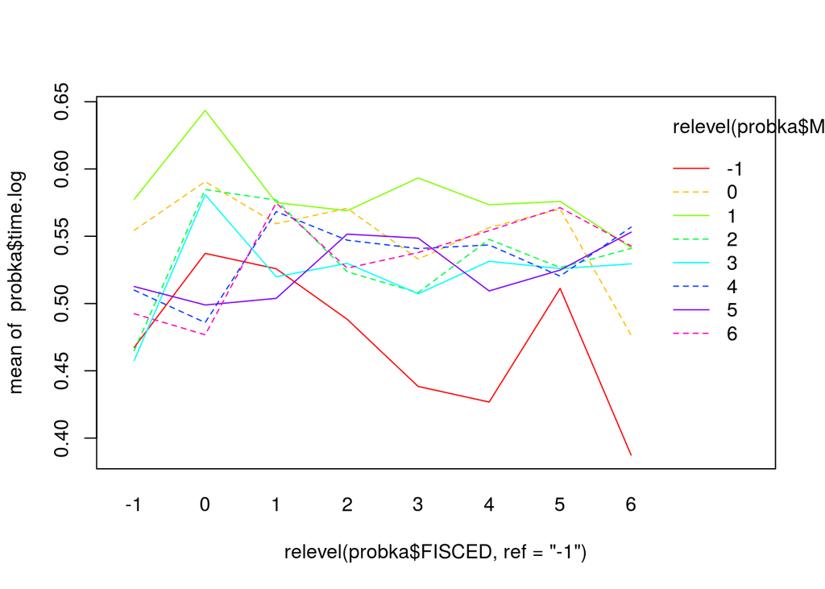

```r
interaction.plot(relevel(probka$FISCED, ref='-1'), relevel(probka$MISCED, ref='-1'), probka$time.log, fixed=T, col=rainbow(length(levels(probka$MISCED))), lty=rep(1:2, length(levels(probka$MISCED))))
```

Wykres wskazuje że mogą występować interakcje.

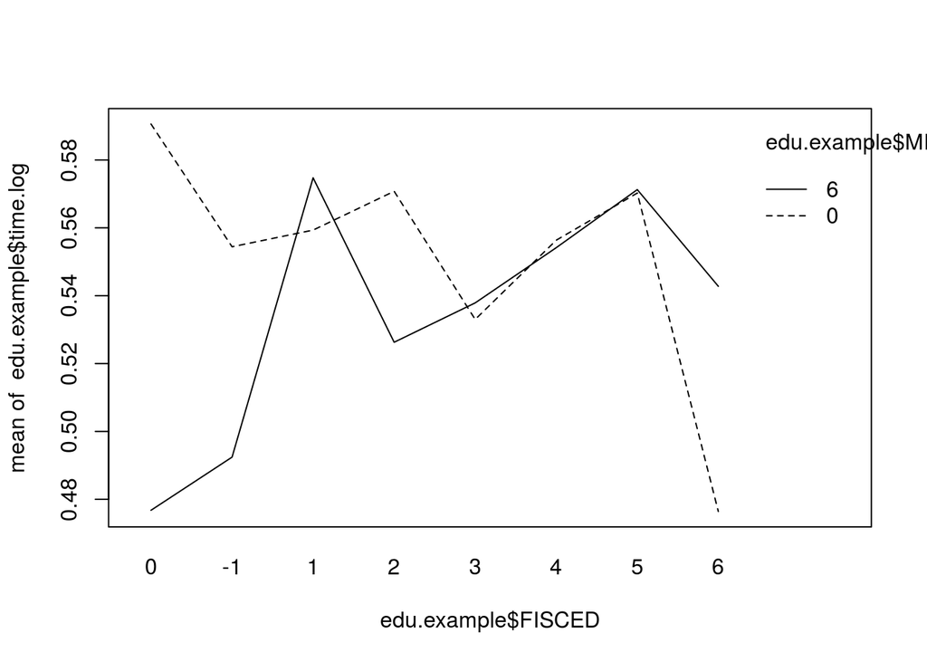

```r
edu.example <- data.frame("MISCED" = factor(probka$MISCED[probka$MISCED %in% c("0", "6")]), "FISCED" = factor(probka$FISCED[probka$MISCED %in% c("0", "6")]), "time.log" = probka$time.log[probka$MISCED %in% c("0", "6")])
interaction.plot(edu.example$FISCED, edu.example$MISCED, edu.example$time.log)
```

```r
edu.full <- lm(time.log ~ FISCED*MISCED, data=probka)
edu.sep <- lm(time.log ~ FISCED + MISCED, data=probka)
anova(edu.full)
```

```
## Analysis of Variance Table
##
## Response: time.log
##                   Df Sum Sq Mean Sq F value    Pr(>F)
## FISCED             7    173 24.7237  73.255 < 2.2e-16 ***
## MISCED             7    133 18.9344  56.102 < 2.2e-16 ***
## FISCED:MISCED     49    221  4.5029  13.342 < 2.2e-16 ***
## Residuals     895510 302234  0.3375
## ---
## Signif. codes:  0 '***' 0.001 '**' 0.01 '*' 0.05 '.' 0.1 ' ' 1
```

```r
anova(edu.full, edu.sep)
```

```
## Analysis of Variance Table
##
## Model 1: time.log ~ FISCED * MISCED
## Model 2: time.log ~ FISCED + MISCED
##   Res.Df    RSS  Df Sum of Sq      F    Pr(>F)
## 1 895510 302234
## 2 895559 302455 -49   -220.64 13.342 < 2.2e-16 ***
## ---
## Signif. codes:  0 '***' 0.001 '**' 0.01 '*' 0.05 '.' 0.1 ' ' 1
```

Test maximum likelihood pokazuje że interakcja jest zauważalna statystycznie.

```r
AIC(edu.full, k=log(nrow(probka))) - AIC(edu.sep, k=log(nrow(probka)))
```

```
## [1] 17.99296
```

```r
AIC(edu.full, k=2) - AIC(edu.sep, k=2)
```

```
## [1] -555.5628
```

Kryterium BIC odrzuca interakcję, a kryterium AIC nie; w obu przypadkach różnica w informacji jest bardzo niewielka.

Dla matek bez wykształcenia czas rozwiązywania maleje wraz z wykształceniem ojca, ale dla matek z najwyższym wykształceniem czas rośnie wraz z wykształceniem ojca. Najlepsze czasy rozwiązywania uzyskują uczniowe którzy nie odpowiedzieli na pytanie o wykształcenie matki; uczniowie ci radzą sobie tym lepiej, im lepiej wykształcony jest ojciec.

Ponieważ zmienne mają dużo poziomów, zbadamy trend zależności poprzez przyjęcie że wykształcenia są zmiennymi numerycznymi. Dzięki temu będziemy mogli odpowiedzieć na pytanie, czy ogólnie rzecz biorąc wykształcenie rodziców ma pozytywny, czy negatywny wpływ na czasy rozwiązywania zadań. Uwzględnimy osobno poziom “-1” poprzez regresję segmentową.

```r
probka$FISCED.int <- as.integer(as.character(probka$FISCED))
probka$FISCED.na <- factor(probka$FISCED == -1)
probka$FISCED.na <- relevel(probka$FISCED.na, ref="TRUE")
probka$MISCED.int <- as.integer(as.character(probka$MISCED))
probka$MISCED.na <- factor(probka$MISCED == -1)
probka$MISCED.na <- relevel(probka$MISCED.na, ref="TRUE")
edu.full.int <- lm(time.log ~ FISCED.na/FISCED.int + MISCED.na/MISCED.int + FISCED.na:MISCED.na:FISCED.int:MISCED.int, data=probka)
edu.sep.int <- lm(time.log ~ FISCED.na/FISCED.int + MISCED.na/MISCED.int, data=probka)
summary(edu.full.int)
```

```
##
## Call:
## lm(formula = time.log ~ FISCED.na/FISCED.int + MISCED.na/MISCED.int +
##     FISCED.na:MISCED.na:FISCED.int:MISCED.int, data = probka)
##
## Residuals:
##      Min       1Q   Median       3Q      Max
## -1.45114 -0.36027 -0.00658  0.37019  1.94198
##
## Coefficients: (2 not defined because of singularities)
##                                                       Estimate Std. Error
## (Intercept)                                          0.4511562  0.0204688
## FISCED.naFALSE                                       0.0757556  0.0104257
## MISCED.naFALSE                                       0.0552081  0.0178872
## FISCED.naTRUE:FISCED.int                                    NA         NA
## FISCED.naFALSE:FISCED.int                           -0.0110804  0.0009199
## MISCED.naTRUE:MISCED.int                                    NA         NA
## MISCED.naFALSE:MISCED.int                           -0.0108645  0.0008798
## FISCED.naTRUE:FISCED.int:MISCED.naTRUE:MISCED.int    0.0162453  0.0212069
## FISCED.naFALSE:FISCED.int:MISCED.naTRUE:MISCED.int   0.0099269  0.0045359
## FISCED.naTRUE:FISCED.int:MISCED.naFALSE:MISCED.int  -0.0085388  0.0026938
## FISCED.naFALSE:FISCED.int:MISCED.naFALSE:MISCED.int  0.0027085  0.0002060
##                                                     t value Pr(>|t|)
## (Intercept)                                          22.041  < 2e-16 ***
## FISCED.naFALSE                                        7.266  3.7e-13 ***
## MISCED.naFALSE                                        3.086  0.00203 **
## FISCED.naTRUE:FISCED.int                                 NA       NA
## FISCED.naFALSE:FISCED.int                           -12.045  < 2e-16 ***
## MISCED.naTRUE:MISCED.int                                 NA       NA
## MISCED.naFALSE:MISCED.int                           -12.349  < 2e-16 ***
## FISCED.naTRUE:FISCED.int:MISCED.naTRUE:MISCED.int     0.766  0.44365
## FISCED.naFALSE:FISCED.int:MISCED.naTRUE:MISCED.int    2.189  0.02863 *
## FISCED.naTRUE:FISCED.int:MISCED.naFALSE:MISCED.int   -3.170  0.00153 **
## FISCED.naFALSE:FISCED.int:MISCED.naFALSE:MISCED.int  13.150  < 2e-16 ***
## ---
## Signif. codes:  0 '***' 0.001 '**' 0.01 '*' 0.05 '.' 0.1 ' ' 1
##
## Residual standard error: 0.5812 on 895565 degrees of freedom
## Multiple R-squared:  0.0007099,  Adjusted R-squared:  0.000701
## F-statistic: 79.53 on 8 and 895565 DF,  p-value: < 2.2e-16
```

```r
summary(edu.sep.int)
```

```
##
## Call:
## lm(formula = time.log ~ FISCED.na/FISCED.int + MISCED.na/MISCED.int,
##     data = probka)
##
## Residuals:
##      Min       1Q   Median       3Q      Max
## -1.42673 -0.36048 -0.00656  0.37009  1.89306
##
## Coefficients: (2 not defined because of singularities)
##                             Estimate Std. Error t value Pr(>|t|)
## (Intercept)                0.4497858  0.0046743  96.226   <2e-16 ***
## FISCED.naFALSE             0.0382548  0.0041305   9.262   <2e-16 ***
## MISCED.naFALSE             0.0609302  0.0053875  11.310   <2e-16 ***
## FISCED.naTRUE:FISCED.int          NA         NA      NA       NA
## FISCED.naFALSE:FISCED.int -0.0007568  0.0004531  -1.670   0.0949 .
## MISCED.naTRUE:MISCED.int          NA         NA      NA       NA
## MISCED.naFALSE:MISCED.int -0.0009046  0.0004540  -1.992   0.0463 *
## ---
## Signif. codes:  0 '***' 0.001 '**' 0.01 '*' 0.05 '.' 0.1 ' ' 1
##
## Residual standard error: 0.5813 on 895569 degrees of freedom
## Multiple R-squared:  0.0004544,  Adjusted R-squared:  0.00045
## F-statistic: 101.8 on 4 and 895569 DF,  p-value: < 2.2e-16
```

```r
anova(edu.full.int, edu.sep.int)
```

```
## Analysis of Variance Table
##
## Model 1: time.log ~ FISCED.na/FISCED.int + MISCED.na/MISCED.int + FISCED.na:MISCED.na:FISCED.int:MISCED.int
## Model 2: time.log ~ FISCED.na/FISCED.int + MISCED.na/MISCED.int
##   Res.Df    RSS Df Sum of Sq      F    Pr(>F)
## 1 895565 302545
## 2 895569 302623 -4   -77.343 57.236 < 2.2e-16 ***
## ---
## Signif. codes:  0 '***' 0.001 '**' 0.01 '*' 0.05 '.' 0.1 ' ' 1
```

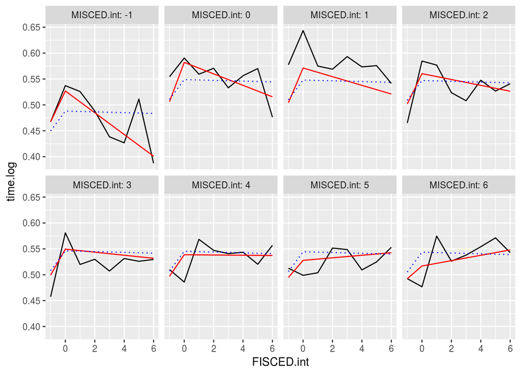

```r
edu.plot.data <- tapply(probka$time.log, list(probka$FISCED, probka$MISCED), mean)
edu.plot.data<- melt(edu.plot.data, varnames=c("FISCED.int", "MISCED.int"), value.name="time.log")
edu.plot.data$MISCED.na <- factor(edu.plot.data$MISCED.int == -1)
edu.plot.data$MISCED.na <- relevel(edu.plot.data$MISCED.na, ref="TRUE")
edu.plot.data$FISCED.na <- factor(edu.plot.data$FISCED.int == -1)
edu.plot.data$FISCED.na <- relevel(edu.plot.data$FISCED.na, ref="TRUE")
edu.plot.data <- cbind(edu.plot.data[,-3], "time.log"=edu.plot.data[,3])
edu.plot.data$time.pred <- predict(edu.full.int, edu.plot.data[,1:4])
edu.plot.data$time.pred2 <- predict(edu.sep.int, edu.plot.data[,1:4])
#edu.plot.data$FISCED <- factor(edu.plot.data$FISCED)
#edu.plot.data$MISCED <- factor(edu.plot.data$MISCED)
ggplot(data=edu.plot.data) + geom_line(aes(x=FISCED.int, y=time.log)) + geom_line(aes(x=FISCED.int, y=time.pred), col=I("red")) + geom_line(aes(x=FISCED.int, y=time.pred2), col=I("blue"), lty=3) + facet_wrap(~MISCED.int, ncol = 4, labeller="label_both")
```

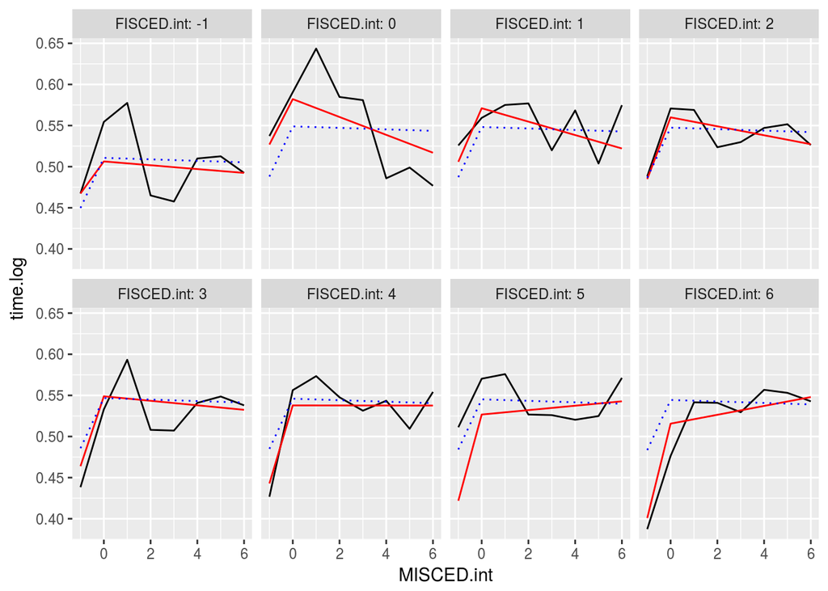

```r
ggplot(data=edu.plot.data) + geom_line(aes(x=MISCED.int, y=time.log)) + geom_line(aes(x=MISCED.int, y=time.pred), col=I("red")) + geom_line(aes(x=MISCED.int, y=time.pred2), col=I("blue"), lty=3) + facet_wrap(~FISCED.int, ncol = 4, labeller="label_both")
```

Widać że trend odwraca odwraca się w stosunku do przerywanej niebieskiej linii, oznaczającej wyniki bez interakcji. Uwzględnienie interakcji pozwoliło na zauważenie że czas rozwiązywania dla matek bez wykształcenia jest tym lepszy, im lepsze wykształcenie ojca, a dla matek z najlepszym wykształceniem jest tym lepszy, im mniejsze wykształcenie ojca.

Powyższy model został zbudowany tylko w oparciu o wykształcenie. Rozpatrzmy teraz pełny model, żeby zweryfikować wyniki. Do pełnego modelu wybierzemy zmienne które miały największy wpływ na wyniki w poprzedniej części (`ST013Q01TA`: liczba książek w domu)

```r
full.model <- lm(time.log ~ task + HEDRES + CNT + ST013Q01TA + WEALTH + BOOKID + gender +  FISCED.na/FISCED.int + MISCED.na/MISCED.int + FISCED.na:MISCED.na:FISCED.int:MISCED.int, data=probka)
anova(full.model)
```

```
## Analysis of Variance Table
##
## Response: time.log
##                                               Df Sum Sq Mean Sq   F value
## task                                          44  23014  523.05 1749.3424
## HEDRES                                         1    110  110.05  368.0679
## CNT                                           54   6343  117.47  392.8642
## ST013Q01TA                                     6    690  115.08  384.8705
## WEALTH                                         1    451  450.79 1507.6693
## BOOKID                                        35   3996  114.17  381.8542
## gender                                         1    270  270.29  903.9993
## FISCED.na                                      1     62   62.34  208.4852
## MISCED.na                                      1     11   10.89   36.4376
## FISCED.na:FISCED.int                           1     24   24.17   80.8324
## MISCED.na:MISCED.int                           1      0    0.02    0.0609
## FISCED.na:FISCED.int:MISCED.na:MISCED.int      4     57   14.37   48.0583
## Residuals                                 895423 267730    0.30
##                                              Pr(>F)
## task                                      < 2.2e-16 ***
## HEDRES                                    < 2.2e-16 ***
## CNT                                       < 2.2e-16 ***
## ST013Q01TA                                < 2.2e-16 ***
## WEALTH                                    < 2.2e-16 ***
## BOOKID                                    < 2.2e-16 ***
## gender                                    < 2.2e-16 ***
## FISCED.na                                 < 2.2e-16 ***
## MISCED.na                                 1.577e-09 ***
## FISCED.na:FISCED.int                      < 2.2e-16 ***
## MISCED.na:MISCED.int                         0.8051
## FISCED.na:FISCED.int:MISCED.na:MISCED.int < 2.2e-16 ***
## Residuals
## ---
## Signif. codes:  0 '***' 0.001 '**' 0.01 '*' 0.05 '.' 0.1 ' ' 1
```

```r
coef(full.model)[(length(coef(full.model))-2):length(coef(full.model))]
```

```
##  FISCED.naFALSE:FISCED.int:MISCED.naTRUE:MISCED.int
##                                         0.014268243
##  FISCED.naTRUE:FISCED.int:MISCED.naFALSE:MISCED.int
##                                        -0.007457892
## FISCED.naFALSE:FISCED.int:MISCED.naFALSE:MISCED.int
##                                         0.002026218
```

Przedstawmy teraz zależnosć graficznie, ustalając pozostałe zmienne na poziomach referencyjnych.

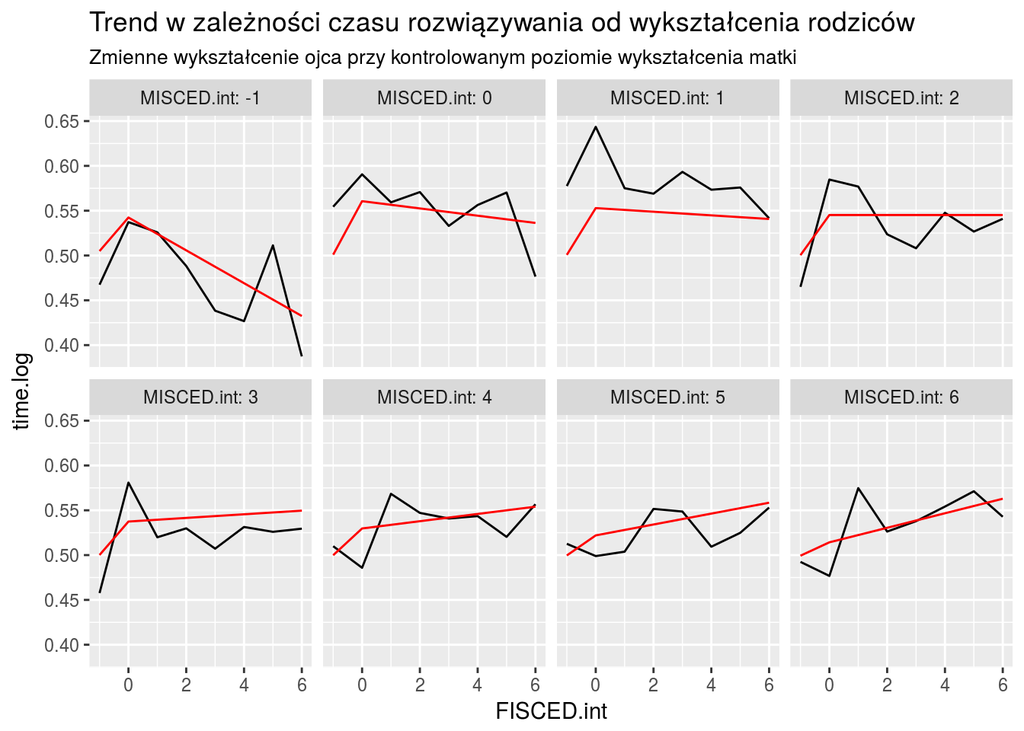

```r
edu.plot.data <- tapply(probka$time.log, list(probka$FISCED.int, probka$MISCED.int), mean) # Obliczamy ponownie po konwersji do numeric
edu.plot.data <- melt(edu.plot.data, varnames=c("FISCED.int", "MISCED.int"), value.name="time.log")
edu.plot.data$MISCED.na <- factor(edu.plot.data$MISCED.int == -1)
edu.plot.data$MISCED.na <- relevel(edu.plot.data$MISCED.na, ref="TRUE")
edu.plot.data$FISCED.na <- factor(edu.plot.data$FISCED.int == -1)
edu.plot.data$FISCED.na <- relevel(edu.plot.data$FISCED.na, ref="TRUE")
full.predict <- predict(full.model, cbind(edu.plot.data[,-3],
                                          'task'= levels(probka$task)[1],
                                          'HEDRES'= 0,
                                          'WEALTH' = 0,
                                          'CNT'= levels(probka$CNT)[1],
                                          'gender'= levels(probka$gender)[1],
                                          'BOOKID' = levels(probka$BOOKID)[1],
                                          'ST013Q01TA' = levels(probka$ST013Q01TA)[1]))
#full.predict <- predict(full.model)
#time.pred <- tapply(full.predict, list(probka$FISCED, probka$MISCED), mean)
#time.pred <- melt(time.pred, varnames = c("FISCED", "MISCED"), value.name="time.pred")
#edu.plot.data$time.pred <- time.pred$time.pred
edu.plot.data$time.pred <- full.predict - mean(full.predict) + mean(edu.plot.data$time.log)
ggplot(data=edu.plot.data) + geom_line(aes(x=FISCED.int, y=time.log)) + geom_line(aes(x=FISCED.int, y=time.pred), col=I("red")) + facet_wrap(~MISCED.int, ncol=4, labeller="label_both") + ggtitle("Trend w zależności czasu rozwiązywania od wykształcenia rodziców", sub="Zmienne wykształcenie ojca przy kontrolowanym poziomie wykształcenia matki")
```

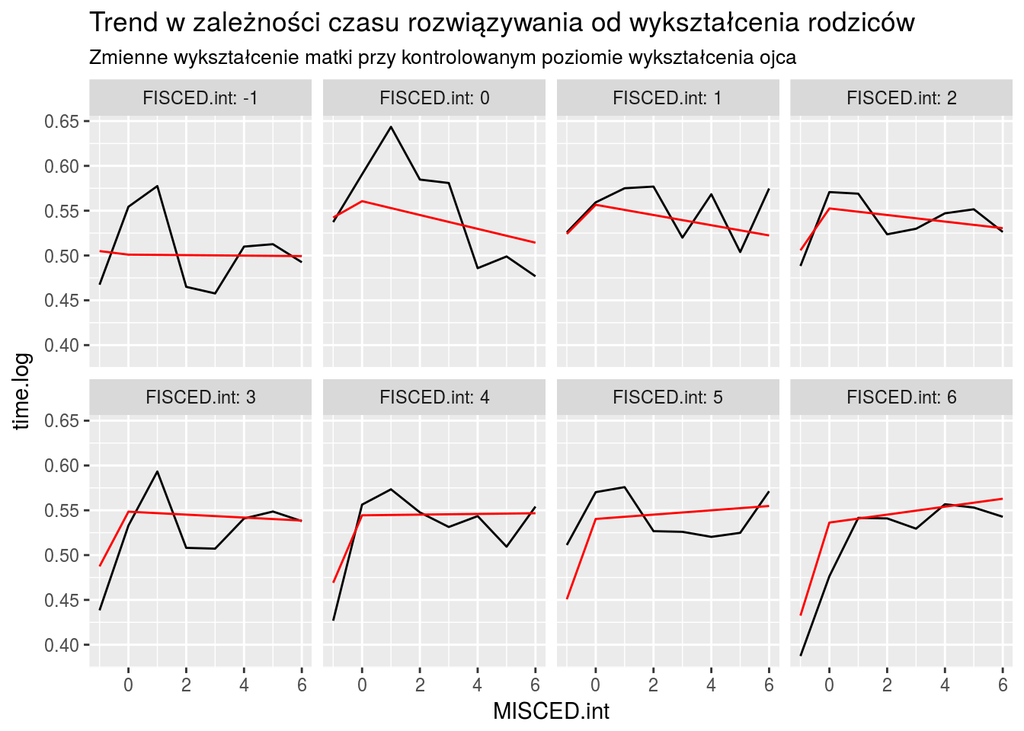

```r
ggplot(data=edu.plot.data) + geom_line(aes(x=MISCED.int, y=time.log)) + geom_line(aes(x=MISCED.int, y=time.pred), col=I("red")) + facet_wrap(~FISCED.int, ncol=4, labeller="label_both") + ggtitle("Trend w zależności czasu rozwiązywania od wykształcenia rodziców", sub="Zmienne wykształcenie matki przy kontrolowanym poziomie wykształcenia ojca")
```

Należy pamiętać, że trend jest opisany trzema parametrami wyestymowanymi dla wszystkich poziomów: zależnością od wykształceń ojca, matki, i interakcją. Opisuje on zatem ogólną zależność, która może być niezgodna dla poszczególnych wartości zmiennych.

Po zbadaniu trendów, w dalszym ciągu będziemy traktować wykształcenia jako zmienne kategoryczne.

```r
rm(edu.full, edu.full.int, edu.sep, edu.sep.int, full.model, edu.plot.data, edu.example, time.full, full.predict)
gc()
```

```
##            used  (Mb) gc trigger   (Mb)  max used   (Mb)
## Ncells  1832519  97.9    4703850  251.3   4703850  251.3
## Vcells 20746246 158.3  546430309 4169.0 653156062 4983.2
```

# 4 Interakcje wykształcenia rodziców z punktacją za zadanie

Możliwe że szybkie rozwiązywanie zadań przez uczniów ze słabo wykształconymi rodzicami nie wynika z lepszego przygotowania, tylko z tego że ci uczniowie częściej strzelają. Rozpatrzmy dodatkowo interakcję z wynikiem zadania, żeby zweryfikować tę hipotezę.

```r
score.model <- lm(time.log ~ S*FISCED*MISCED, data=probka)
anova(score.model)
```

```
## Analysis of Variance Table
##
## Response: time.log
##                     Df Sum Sq Mean Sq   F value    Pr(>F)
## S                    3   4332 1444.09 4348.2394 < 2.2e-16 ***
## FISCED               7    187   26.68   80.3341 < 2.2e-16 ***
## MISCED               7    139   19.79   59.5848 < 2.2e-16 ***
## S:FISCED            21    326   15.50   46.6760 < 2.2e-16 ***
## S:MISCED            21     72    3.41   10.2701 < 2.2e-16 ***
## FISCED:MISCED       49    227    4.64   13.9597 < 2.2e-16 ***
## S:FISCED:MISCED    130    129    0.99    2.9944 < 2.2e-16 ***
## Residuals       895335 297349    0.33
## ---
## Signif. codes:  0 '***' 0.001 '**' 0.01 '*' 0.05 '.' 0.1 ' ' 1
```

ANOVA wskazuje że interakcje punktacji z wykształceniem są istotne.

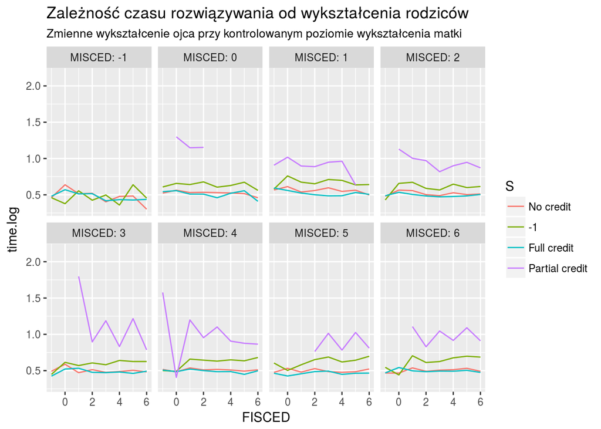

```r
# UWAGA: Nie wszystkie poziomy mają obserwacje!
score.plot.data <- tapply(probka$time.log, list(probka$FISCED, probka$MISCED, probka$S), mean)
score.plot.data <- melt(score.plot.data, varnames=c("FISCED", "MISCED", "S"), value.name="time.log")
score.plot.data$S <- factor(score.plot.data$S)
ggplot(data=score.plot.data) + geom_line(aes(x=FISCED, y=time.log, color=S)) + facet_wrap(~MISCED, ncol=4, labeller="label_both") + ggtitle("Zależność czasu rozwiązywania od wykształcenia rodziców", sub="Zmienne wykształcenie ojca przy kontrolowanym poziomie wykształcenia matki")
```

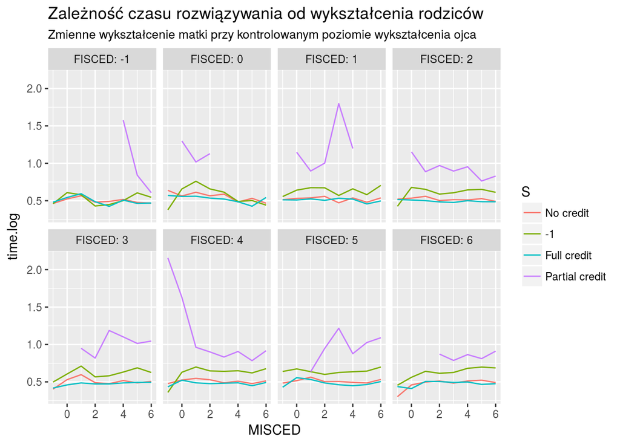

```r
ggplot(data=score.plot.data) + geom_line(aes(x=MISCED, y=time.log, color=S)) + facet_wrap(~FISCED, ncol=4, labeller="label_both") + ggtitle("Zależność czasu rozwiązywania od wykształcenia rodziców", sub="Zmienne wykształcenie matki przy kontrolowanym poziomie wykształcenia ojca")
```

Efekt punktacji wydaje się addytywny, nie widać jednoznacznych zmian trendów. Zależność jest trudna do zinterpretowania ze względu na dużą liczbę poziomów zmiennych oraz brakujące obserwacje dla niektórych grup, w szczególności “Partial credit”. Z tego powodu przyjrzymy się tej zależności bliżej po przekodowaniu poziomów wykształcenia w następnym etapie.

```r
rm(score.int, score.model, full.predict, score.plot.data)
gc()
```

```
##            used  (Mb) gc trigger   (Mb)  max used   (Mb)
## Ncells  1841783  98.4    4703850  251.3   4703850  251.3
## Vcells 20750766 158.4  691170157 5273.3 758257181 5785.1
```

# 5 Interakcje wykształcenia rodziców z płcią dziecka

Wykształcenie rodziców może mieć rózny wpływ na dziecko w zależności od jego płci. Zbudujmy najpierw model pomocniczy do zweryfikowania tej hipotezy.

```r
gender.model <- lm(time.log ~ gender*FISCED*MISCED, data=probka)
anova(gender.model)
```

```
## Analysis of Variance Table
##
## Response: time.log
##                          Df Sum Sq Mean Sq   F value    Pr(>F)
## gender                    1    455  454.67 1349.5204 < 2.2e-16 ***
## FISCED                    7    168   23.98   71.1706 < 2.2e-16 ***
## MISCED                    7    128   18.24   54.1454 < 2.2e-16 ***
## gender:FISCED             7     22    3.21    9.5203 7.037e-12 ***
## gender:MISCED             7      9    1.35    3.9984  0.000221 ***
## FISCED:MISCED            49    215    4.40   13.0497 < 2.2e-16 ***
## gender:FISCED:MISCED     49     73    1.49    4.4218 < 2.2e-16 ***
## Residuals            895446 301690    0.34
## ---
## Signif. codes:  0 '***' 0.001 '**' 0.01 '*' 0.05 '.' 0.1 ' ' 1
```

Model wskazuje że interakcje rzeczywiście występują. Przyjrzyjmy się trendom, korzystając z formuły z poprzedniej sekcji.

```r
gender.int.model <- lm(time.log ~ task + HEDRES + CNT + ST013Q01TA + WEALTH + BOOKID + gender*(FISCED.na/FISCED.int + MISCED.na/MISCED.int + FISCED.na:MISCED.na:FISCED.int:MISCED.int), data=probka)
anova(gender.int.model)
```

```
## Analysis of Variance Table
##
## Response: time.log
##                                                      Df Sum Sq Mean Sq
## task                                                 44  23014  523.05
## HEDRES                                                1    110  110.05
## CNT                                                  54   6343  117.47
## ST013Q01TA                                            6    690  115.08
## WEALTH                                                1    451  450.79
## BOOKID                                               35   3996  114.17
## gender                                                1    270  270.29
## FISCED.na                                             1     62   62.34
## MISCED.na                                             1     11   10.89
## FISCED.na:FISCED.int                                  1     24   24.17
## MISCED.na:MISCED.int                                  1      0    0.02
## gender:FISCED.na                                      1      5    4.60
## gender:MISCED.na                                      1      0    0.42
## gender:FISCED.na:FISCED.int                           1     10    9.61
## gender:MISCED.na:MISCED.int                           1      5    5.01
## FISCED.na:FISCED.int:MISCED.na:MISCED.int             4     57   14.31
## gender:FISCED.na:FISCED.int:MISCED.na:MISCED.int      4      8    2.07
## Residuals                                        895415 267703    0.30
##                                                    F value    Pr(>F)
## task                                             1749.5076 < 2.2e-16 ***
## HEDRES                                            368.1026 < 2.2e-16 ***
## CNT                                               392.9013 < 2.2e-16 ***
## ST013Q01TA                                        384.9068 < 2.2e-16 ***
## WEALTH                                           1507.8117 < 2.2e-16 ***
## BOOKID                                            381.8903 < 2.2e-16 ***
## gender                                            904.0846 < 2.2e-16 ***
## FISCED.na                                         208.5049 < 2.2e-16 ***
## MISCED.na                                          36.4411 1.574e-09 ***
## FISCED.na:FISCED.int                               80.8401 < 2.2e-16 ***
## MISCED.na:MISCED.int                                0.0609    0.8051
## gender:FISCED.na                                   15.3972 8.712e-05 ***
## gender:MISCED.na                                    1.4025    0.2363
## gender:FISCED.na:FISCED.int                        32.1333 1.440e-08 ***
## gender:MISCED.na:MISCED.int                        16.7421 4.282e-05 ***
## FISCED.na:FISCED.int:MISCED.na:MISCED.int          47.8776 < 2.2e-16 ***
## gender:FISCED.na:FISCED.int:MISCED.na:MISCED.int    6.9095 1.477e-05 ***
## Residuals
## ---
## Signif. codes:  0 '***' 0.001 '**' 0.01 '*' 0.05 '.' 0.1 ' ' 1
```

```r
coef(gender.int.model)[(length(coef(gender.int.model))-5):length(coef(gender.int.model))]
```

```
##          FISCED.naTRUE:FISCED.int:MISCED.naFALSE:MISCED.int
##                                                -0.009878741
##         FISCED.naFALSE:FISCED.int:MISCED.naFALSE:MISCED.int
##                                                 0.002945702
##   gender2:FISCED.naTRUE:FISCED.int:MISCED.naTRUE:MISCED.int
##                                                -0.103915241
##  gender2:FISCED.naFALSE:FISCED.int:MISCED.naTRUE:MISCED.int
##                                                 0.022552422
##  gender2:FISCED.naTRUE:FISCED.int:MISCED.naFALSE:MISCED.int
##                                                 0.004227123
## gender2:FISCED.naFALSE:FISCED.int:MISCED.naFALSE:MISCED.int
##                                                -0.001780641
```

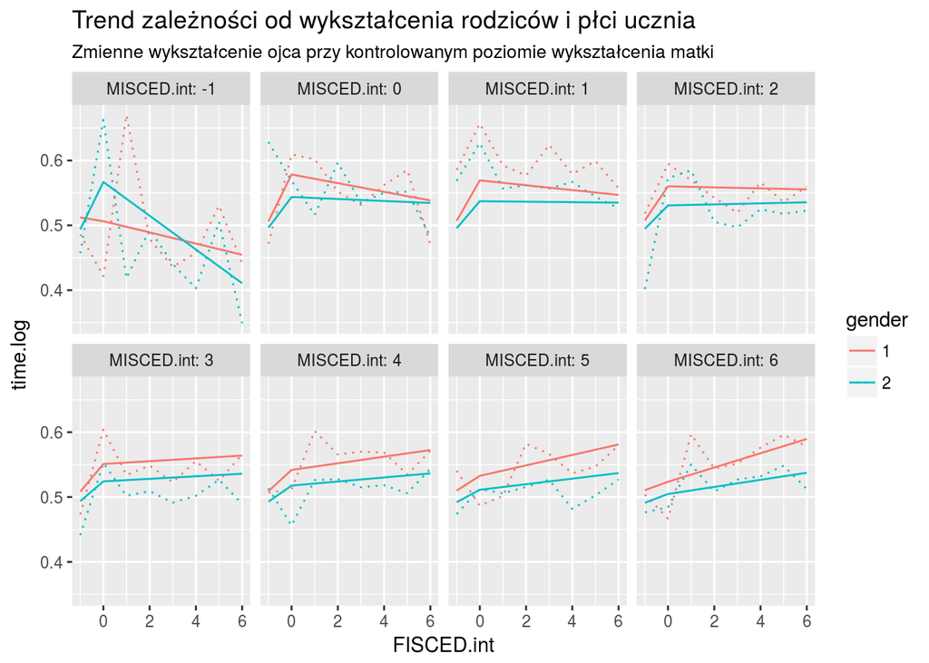

```r
gender.plot.data <- tapply(probka$time.log, list(probka$FISCED.int, probka$MISCED.int, probka$gender), mean)
gender.plot.data <- melt(gender.plot.data, varnames=c("FISCED.int", "MISCED.int", "gender"), value.name="time.log")
gender.plot.data$MISCED.na <- factor(gender.plot.data$MISCED.int == -1)
gender.plot.data$MISCED.na <- relevel(gender.plot.data$MISCED.na, ref="TRUE")
gender.plot.data$FISCED.na <- factor(gender.plot.data$FISCED.int == -1)
gender.plot.data$FISCED.na <- relevel(gender.plot.data$FISCED.na, ref="TRUE")
gender.plot.data$gender <- factor(gender.plot.data$gender)
time.pred <- predict(gender.int.model, cbind(gender.plot.data[,-4],
                                       'task'= levels(probka$task)[1],
                                       'HEDRES'= 0,
                                       'WEALTH' = 0,
                                       'CNT'= levels(probka$CNT)[1],
                                       'BOOKID' = levels(probka$BOOKID)[1],
                                       'ST013Q01TA' = levels(probka$ST013Q01TA)[1]))
gender.plot.data$time.pred <- time.pred - mean(time.pred) + mean(gender.plot.data$time.log)
ggplot(data=gender.plot.data) + geom_line(aes(x=FISCED.int, y=time.log, color=gender), lty=3) + geom_line(aes(x=FISCED.int, y=time.pred, color=gender)) + facet_wrap(~MISCED.int, ncol=4, labeller = "label_both") +  ggtitle("Trend zależności od wykształcenia rodziców i płci ucznia", sub="Zmienne wykształcenie ojca przy kontrolowanym poziomie wykształcenia matki")
```

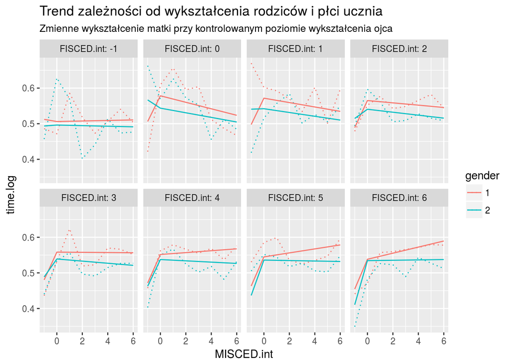

```r
ggplot(data=gender.plot.data) + geom_line(aes(x=MISCED.int, y=time.log, color=gender), lty=3) + geom_line(aes(x=MISCED.int, y=time.pred, color=gender)) + facet_wrap(~FISCED.int, ncol=4, labeller = "label_both") + ggtitle("Trend zależności od wykształcenia rodziców i płci ucznia", sub="Zmienne wykształcenie matki przy kontrolowanym poziomie wykształcenia ojca")
```

Uczniowie którzy nie odpowiedzieli na pytanie o matkę mają zdecydowanie lepsze rezultaty jeśli ich ojciec jest dobrze wykształcony. Podobny efekt występuje dla uczennic, ale jest słabszy. Co ciekawe, nie ma takiej zależności dla uczennic ani uczniów którzy nie odpowiedzieli na pytanie o ojca.

W przypadku niewykształconej matki (`MISCED=0`), wykształcenie ojca ma korzystny wpływ na czas rozwiązywania zadań dla obu płci, ale bardziej korzysny dla uczennic W przypadku dobrze wykształconego ojca (`FISCED = 6`) wpływ wykształcenia matki na czas rozwiązywania zadań jest nieznaczny dla uczniów, a zdecydowanie większy dla uczennic.

Wartości statystyki F dla interakcji są niewielkie w porównaniu z pozostałymi zmiennymi, dlatego pominiemy te interakcje na dalszych etapach.

```r
rm(gender.plot.data, time.pred, gender.int.model, gender.model)
gc()
```

```
##           used (Mb) gc trigger  (Mb) max used  (Mb)
## Ncells 1666385 89.0    2637877 140.9  2164898 115.7
## Vcells 2097155 16.1    3851194  29.4  2936925  22.5
```

# 6 Interakcja płeć - kraj

Ze względu na różnice kulturowe, w różnych krajach możemy spodziewać się różnych zależności od płci.

```r
cnt.model <- lm(time.log ~ gender*CNT, data=probka)
anova(cnt.model)
```

```
## Analysis of Variance Table
##
## Response: time.log
##                Df Sum Sq Mean Sq  F value    Pr(>F)
## gender          1    455  454.67 1373.016 < 2.2e-16 ***
## CNT            54   5525  102.31  308.960 < 2.2e-16 ***
## gender:CNT     54    248    4.59   13.852 < 2.2e-16 ***
## Residuals  895464 296533    0.33
## ---
## Signif. codes:  0 '***' 0.001 '**' 0.01 '*' 0.05 '.' 0.1 ' ' 1
```

Zależność jest zauważalna statystycznie, ale ma bardzo niewielką wartość statystyki F, zatem wyjaśnia mało zmienności w danych. Pomimo tego warto przyjrzeć się bliżej tej interakcji, ponieważ jest interesująca sama w sobie. Stwórzmy zatem pełny model.

```r
full.model <- lm(time.log ~  task + HEDRES + CNT + ST013Q01TA + WEALTH + BOOKID + FISCED + MISCED + gender*CNT, data=probka)
anova(full.model)
```

```
## Analysis of Variance Table
##
## Response: time.log
##                Df Sum Sq Mean Sq  F value    Pr(>F)
## task           44  23014  523.05 1750.813 < 2.2e-16 ***
## HEDRES          1    110  110.05  368.377 < 2.2e-16 ***
## CNT            54   6343  117.47  393.195 < 2.2e-16 ***
## ST013Q01TA      6    690  115.08  385.194 < 2.2e-16 ***
## WEALTH          1    451  450.79 1508.937 < 2.2e-16 ***
## BOOKID         35   3996  114.17  382.175 < 2.2e-16 ***
## FISCED          7     93   13.33   44.615 < 2.2e-16 ***
## MISCED          7     63    9.02   30.197 < 2.2e-16 ***
## gender          1    271  271.00  907.130 < 2.2e-16 ***
## CNT:gender     54    241    4.46   14.915 < 2.2e-16 ***
## Residuals  895363 267487    0.30
## ---
## Signif. codes:  0 '***' 0.001 '**' 0.01 '*' 0.05 '.' 0.1 ' ' 1
```

```r
cnt.time <- data.frame("Kraj" = levels(probka$CNT))
# poziom gender2 to bazowy gender gap dla Polski (nie ma interakcji płci z Polską), więc wstawiamy 0
cnt.time$Interakcja <- c(0, coef(full.model)[sapply(cnt.time$Kraj[-1], function(x)
                                             grep(str_c(x, ":gender"), names(coef(full.model))))])
# Dodajemy bazowy gender gap
cnt.time$Interakcja <- cnt.time$Interakcja + coef(full.model)["gender2"]
malMap <- joinCountryData2Map(cnt.time, joinCode = "ISO3",
  nameJoinColumn = "Kraj")
```

```
## 52 codes from your data successfully matched countries in the map
## 3 codes from your data failed to match with a country code in the map
## 191 codes from the map weren't represented in your data
```

```r
pal <- brewer.pal(11, name="RdBu")[1:8]
# as.hexmode(as.integer(as.hexmode('FFFFFF')) - as.integer(as.hexmode('92C5DE')))
mapParams <- mapCountryData(malMap, nameColumnToPlot="Interakcja", colourPalette=pal, catMethod = "pretty",
  missingCountryCol = gray(0.8), mapTitle="Gender gap", lwd=0.4, borderCol="black", addLegend=F)
```

```
## You asked for 7 categories, 9 were used due to pretty() classification
```

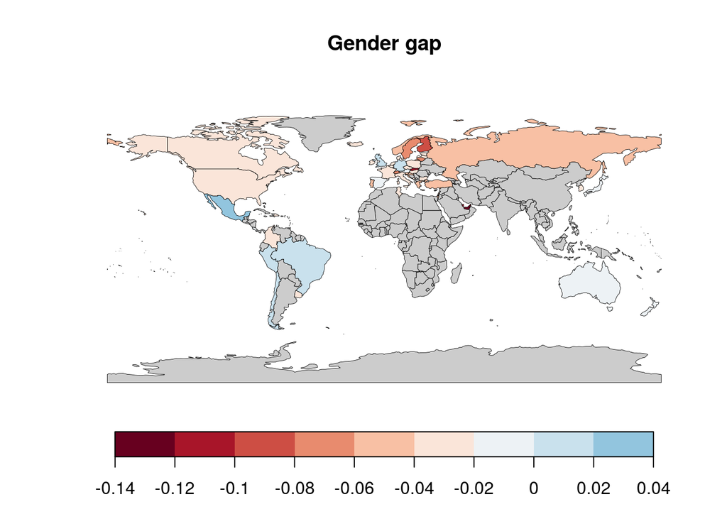

```r
do.call(addMapLegend, c(mapParams, legendLabels='all'))
```

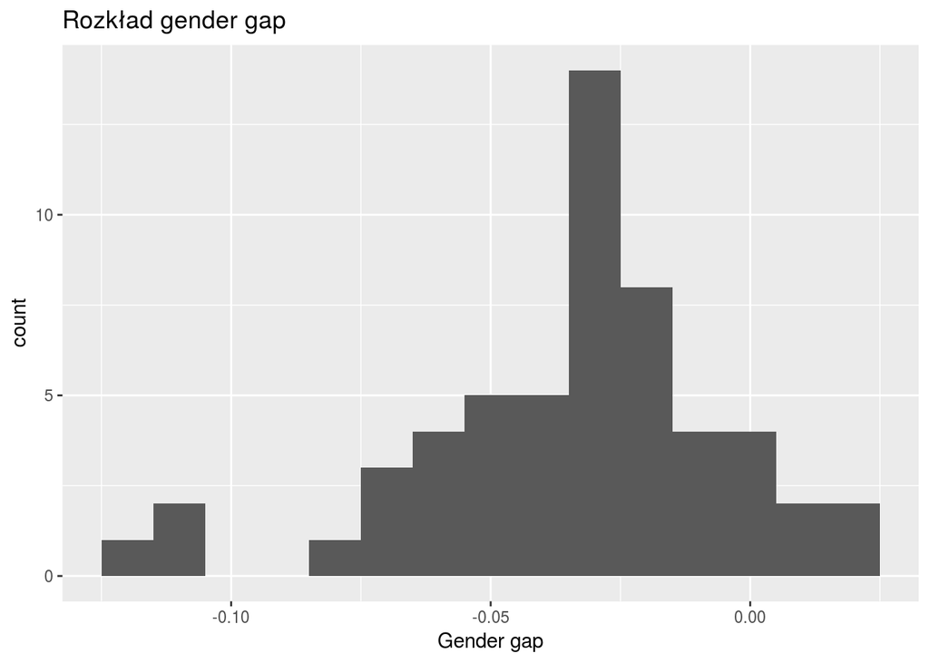

```r
qplot(cnt.time$Interakcja, main="Rozkład gender gap", binwidth=0.01, xlab="Gender gap")
```

Widać, że w większości krajów są większe różnice pomiędzy uczniami a uczennicami niż w Polsce (gender gap równy -0.0220906), najczęściej na korzyść uczniów. Jednakże w wielu krajach Ameryki południowej oraz niektórych krajach Europy zachodniej uczennice radzą sobie lepiej niż uczniowie.

W dalszym ciągu pominiemy tę interakcję, ponieważ wyjaśnia bardzo mało zmienności w danych.

```r
rm(cnt.time, cnt.gender, cnt.model, full.model, malMap, mapParams, time.pred)
gc()
```

```
##            used  (Mb) gc trigger   (Mb)  max used   (Mb)
## Ncells  1813209  96.9    3886542  207.6   3886542  207.6
## Vcells 20690824 157.9  603912766 4607.5 705374968 5381.6
```

# 7 Interakcje zasobów edukacyjnych i płci

Zbadamy, czy któraś z płci jest bardziej podatna na korzystanie z zasobów edukacyjnych.

```r
hedres.model <- lm(time.log ~ HEDRES*gender, data=probka)
anova(hedres.model)
```

```
## Analysis of Variance Table
##
## Response: time.log
##                   Df Sum Sq Mean Sq  F value    Pr(>F)
## HEDRES             1    112  111.86  331.510 < 2.2e-16 ***
## gender             1    450  450.24 1334.302 < 2.2e-16 ***
## HEDRES:gender      1      3    3.42   10.144  0.001447 **
## Residuals     895570 302195    0.34
## ---
## Signif. codes:  0 '***' 0.001 '**' 0.01 '*' 0.05 '.' 0.1 ' ' 1
```

Różnice są bardzo nieznaczne, więc nie będziemy rozpatrywać tej interakcji.

```r
rm(hedres.model)
```

# 8 Interakcje zasobów edukacyjnych i wskaźnika zamożności

```r
hd.we.model <- lm(time.log ~ HEDRES*WEALTH, data=probka)
anova(hd.we.model)
```

```
## Analysis of Variance Table
##
## Response: time.log
##                   Df Sum Sq Mean Sq  F value Pr(>F)
## HEDRES             1    112  111.86  332.524 <2e-16 ***
## WEALTH             1   1375 1375.18 4087.896 <2e-16 ***
## HEDRES:WEALTH      1      0    0.16    0.484 0.4866
## Residuals     895570 301273    0.34
## ---
## Signif. codes:  0 '***' 0.001 '**' 0.01 '*' 0.05 '.' 0.1 ' ' 1
```

Wartość statystyki F jest bardzo niewielka, więc nie uwzględnimy tej interakcji.

```r
rm(hd.we.model)
```

# 9 Interakcje zmiennych z punktacją

Z punktu widzenia interpretacji wyników najważniejszą interakcją jest interakcja z wynikiem zadania. W poprzednich etapach odkryliśmy, że w przypadku niektórych zadań rozkład czasu rozwiązywania jest dwumodalny. Może to być powodowane tym, że niektórzy uczniowie strzelają zamiast odpowiadać na pytania; Spodziewamy się, że uwzględnienie punktacji wykryje strzelców.

Przeprowadzimy wybór modelu za pomocą kryterium BIC. Rmarkdown nie kompiluje poniższego kodu ponieważ brakuje pamięci, więc wyniki podamy w tekście.

```r
modelBase <- lm(time.log ~ S*(task + HEDRES + ST013Q01TA + WEALTH + BOOKID + FISCED*MISCED + gender) + CNT, data = probka)
anova(modelBase)
cat("AIC: ", AIC(modelBase), " BIC: ", BIC(modelBase), '\n')
rm(modelBase)
gc()
```

AIC wynosi `1400506`, a BIC `1407132`.

Usuńmy interakcje które mają małą wartość statystyki F.

```r
modelBase <- lm(time.log ~ S*(task + HEDRES + ST013Q01TA + WEALTH + FISCED) + BOOKID + FISCED + MISCED + gender + CNT, data = probka)
anova(modelBase)
cat("AIC: ", AIC(modelBase), " BIC: ", BIC(modelBase), '\n')
```

AIC wynosi `1402306`, a BIC `1405653`. Na podstawie kryterium BIC wybieramy mniejszy model.

# 10 Wizualizacja

```r
modelBase <- lm(time.log ~ S*(task + HEDRES + WEALTH), data = probka)
```

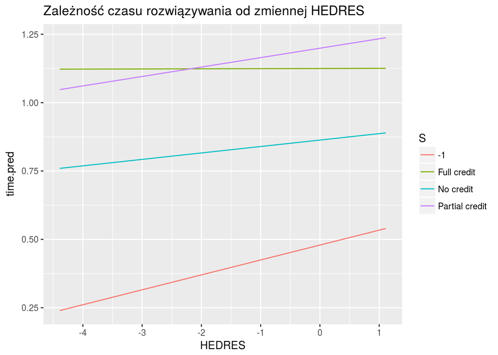

```r
hedres.bins <- seq(min(probka$HEDRES), max(probka$HEDRES), by=0.1)
hedres.plot.data <- data.frame("HEDRES"=rep(hedres.bins, length(levels(probka$S))), "S"=rep(levels(probka$S), each=length(hedres.bins)))
hedres.plot.data$S <- factor(hedres.plot.data$S)
hedres.plot.data$time.pred <- predict(modelBase, cbind(hedres.plot.data,
                                       'task'= levels(probka$task)[1],
                                       'WEALTH' = 0,
                                       'FISCED' = levels(probka$FISCED)[1],
                                       'MISCED' = levels(probka$MISCED)[1],
                                       'gender' = levels(probka$gender)[1],
                                       'CNT'= levels(probka$CNT)[1],
                                       'BOOKID' = levels(probka$BOOKID)[1],
                                       'ST013Q01TA' = levels(probka$ST013Q01TA)[1]))
ggplot(data=hedres.plot.data) + geom_line(aes(x=HEDRES, y=time.pred, col=S)) + xlab("HEDRES") + ggtitle("Zależność czasu rozwiązywania od zmiennej HEDRES")
```

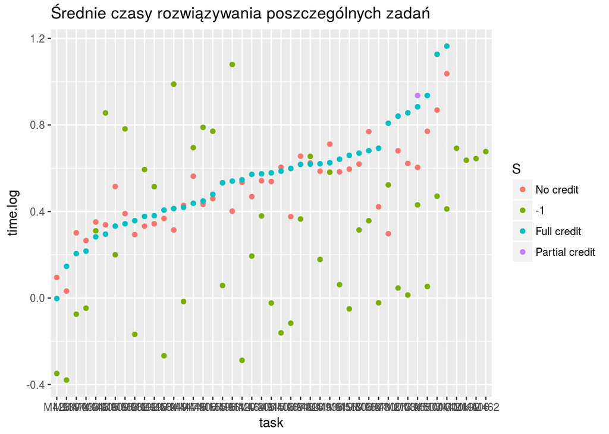

```r
task.plot.data <- tapply(probka$time.log, list(probka$task, probka$S), mean)
task.plot.data <- melt(task.plot.data, varnames=c("task", "S"), value.name = "time.log")
task.plot.data$S <- factor(task.plot.data$S)
task.plot.data$task <- factor(task.plot.data$task, levels=unique(task.plot.data$task[order(task.plot.data[task.plot.data$S == "Full credit", "time.log"])]))
ggplot(data=task.plot.data) + geom_point(aes(x=task, y=time.log, col=S)) + ggtitle("Średnie czasy rozwiązywania poszczególnych zadań")
```

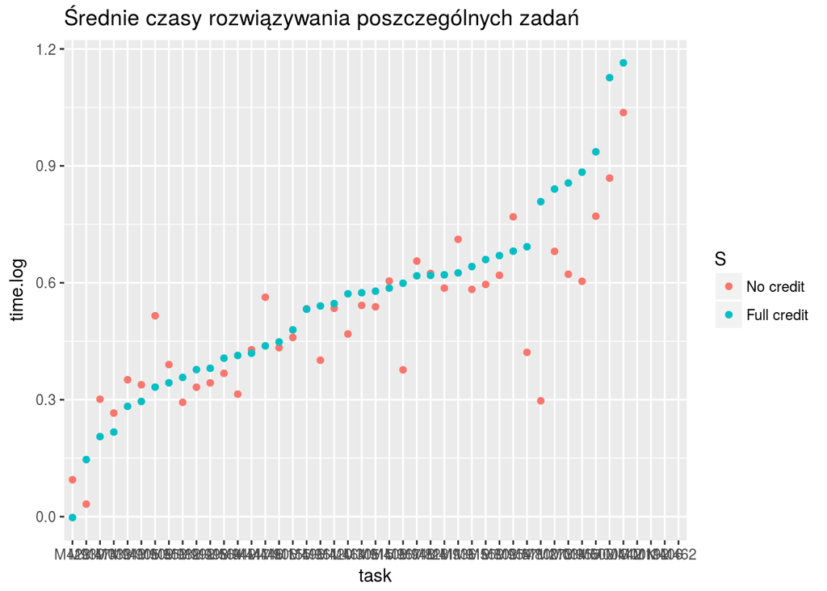

```r
ggplot(data=task.plot.data[task.plot.data$S %in% c("Full credit", "No credit"), ]) + geom_point(aes(x=task, y=time.log, col=S)) + ggtitle("Średnie czasy rozwiązywania poszczególnych zadań")
```

Punktacja częściowa wystąpiła tylko w przypadku jednego zadania: `M955`. W przypadku niektórych zadań błędne rozwiązanie zajmowało uczniom więcej czasu niż poprawne.

Przyjrzyjmy się bliżej czasom rozwiązania w zależności od punktacji:

```r
lsd <- LSD.test(modelBase, "S", p.adj = 'bonferroni', alpha=0.001)
print(lsd)
```

```
## $statistics
##        Mean       CV   MSerror
##   0.5398059 100.2096 0.2926131
##
## $parameters
##       Df ntr bonferroni alpha       test name.t
##   895438   4    3.76484 0.001 bonferroni      S
##
## $means
##                 time.log       std      r       LCL       UCL        Min
## -1             0.6441878 0.6955948 266272 0.6407383 0.6476372 -0.8832305
## Full credit    0.4831220 0.4893673 305229 0.4799002 0.4863438 -0.8800107
## No credit      0.5066327 0.5458305 323472 0.5035031 0.5097624 -0.8796893
## Partial credit 0.9361247 0.4548977    601 0.8635180 1.0087314 -0.7845424
##                     Max
## -1             2.342845
## Full credit    2.342845
## No credit      2.342845
## Partial credit 2.163248
##
## $comparison
## NULL
##
## $groups
##              trt     means M
## 1 Partial credit 0.9361247 a
## 2             -1 0.6441878 b
## 3      No credit 0.5066327 c
## 4    Full credit 0.4831220 d
```

Wszystkie grupy punktacji mają zauważalnie różne czasy rozwiązywania zadań. Wyraźnie odstaje tutaj punktacja częściowa (“Partial credit”); uczniowie którzy dostali częściową punktację rozwiązywali zadanie zdecydowanie dłużej niż ci którzy dostali pełną punktację (czas jest transformowany, więc na podstawie testu nie można precyzyjnie określić o ile dłużej).

Wyniki pozornie są niezgodne z poprzednim wykresem obrazującym średnie czasy rozwiązywania poszczególnych zadań, ponieważ na wykresie wydaje się że w przypadku większości zadań czas potrzebny na otrzymanie pełnej punktacji jest na ogół większy niż czas potrzebny na błędne rozwiązanie zadania. Różnice wynikają z nierównomiernej liczby rozwiązań poszczególnych zadań:

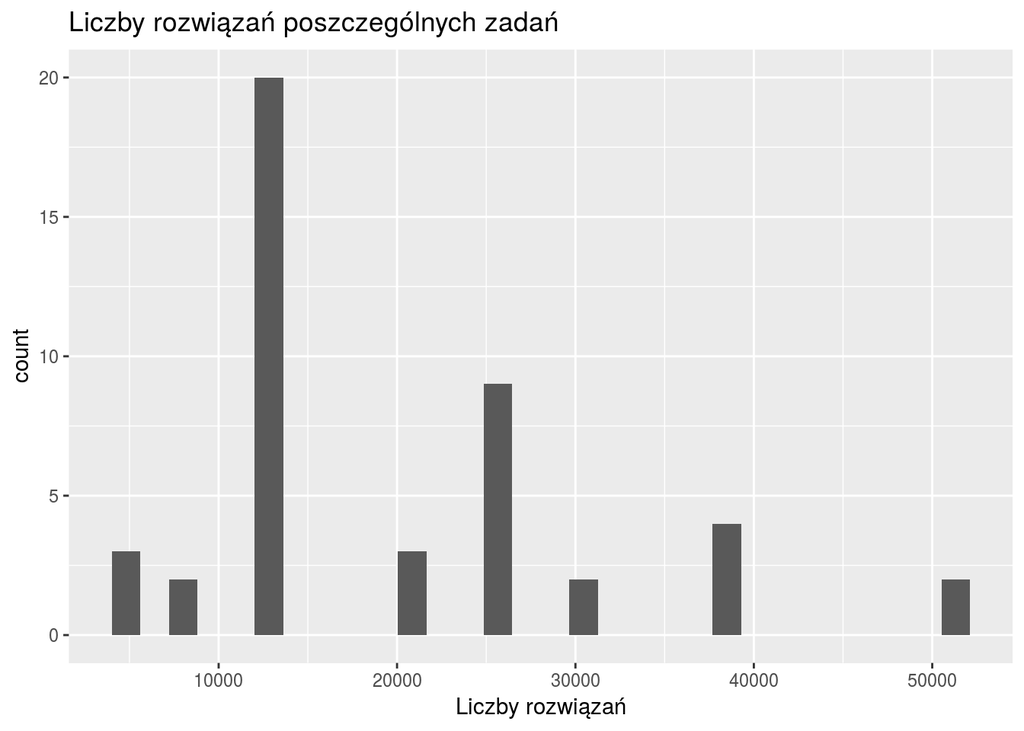

```r
qplot(tapply(probka$time.log, probka$task, length), main="Liczby rozwiązań poszczególnych zadań", xlab="Liczby rozwiązań")
```

```r
rm(modelBase)
gc()
```

```
##             used   (Mb) gc trigger   (Mb)  max used   (Mb)
## Ncells   2701214  144.3    4703850  251.3   3886542  207.6
## Vcells 222635664 1698.6  709965776 5416.7 834220168 6364.6
```